# A Brief History of Steves

Steve Kasica ([@swkasica](https://twitter.com/swkasica))

Feb. 8, 2019

https://github.com/swkasica/a_brief_history_of_steves

[interactive chart not shown]

## The Axis of St-evil

[figure not shown]

### The Axis of St-evil: Steve Mnuchin

[figure not shown]

### The Axis of St-evil: Stephen Miller

[figure not shown]

### The Axis of St-evil: Steve Bannon

[figure not shown]

## Outline

- What is a Steve?
  - Stephen vs. Steven
- Steves in Modern History
  - Artists
  - Scientists
  - Athletes
- Steves in Popular Culture

## What is a Steve?

[figure not shown]

[Source: Scholastic](https://www.scholastic.com)

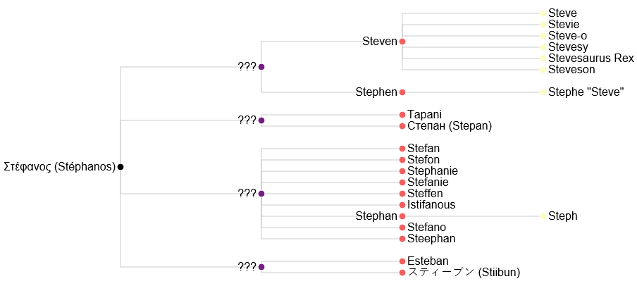

```python
Vega(treeSchema)
```

### Stephen vs. Steven

Stephen > Steven

[figure not shown]

### Stephen vs. Steven

[figure not shown]

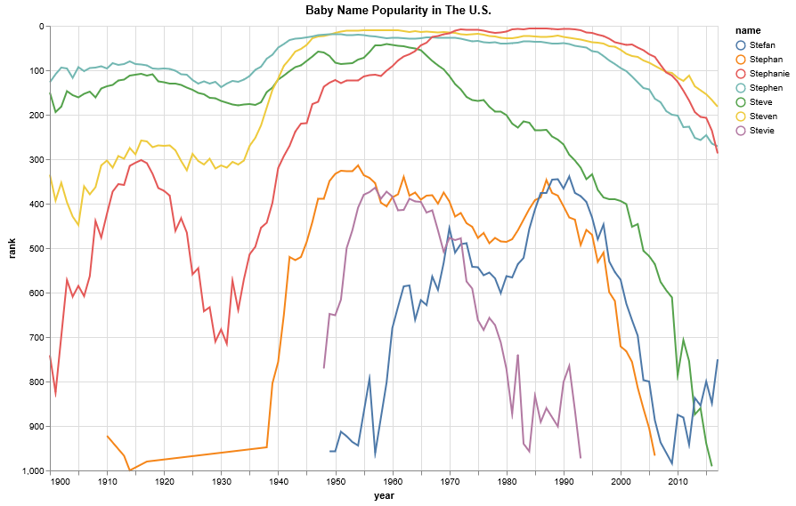

```python
VegaLite(baby_names)
```

> "If you forget an old white guy's name, you have a descent chance if you just throw out a Steve."  
> -- Seth Meyers, *Late Night with Seth Meyers*, Jan. 6, 2019

## Steves in Modern History

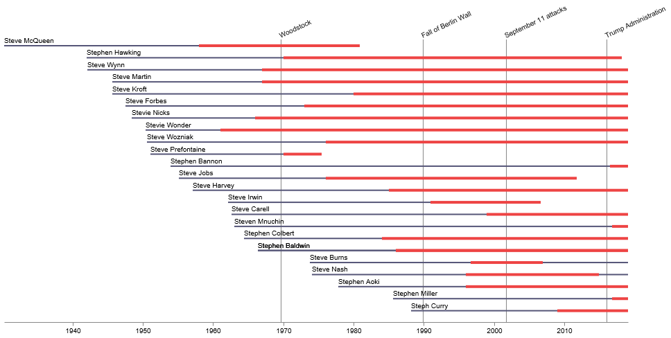

```python
Vega(timeline)
```

## Steves are Artists

[figure not shown]

### Stevie Nicks

[figure not shown]

- Born May 26, 1948
- One of the greatest songwriters of all time
- Vocalists in Fleetwood Mac

## Steves are Curious

[figure not shown]

### Stephen Hawking: Theoretical Physicist

[figure not shown]

- Jan. 8, 1942 - March 14, 2018
- Diagnosed with ALS at age 21
- Pop Culture Icon

### Stephen Jay Gould: Evolutionary Biologist

[figure not shown]

- September 10, 1941, - May 20, 2002
- Authored 300 popular essays in *Natural History* magazine
- Project Steve

## Steves are athletic

[figure not shown]

### Steph Curry

[figure not shown]

- Wardell Stephen Curry II
- Born March 14, 1988
- Plays for Golden State Warriors

## One Steve is good

## But Steve + Steve =

[figure not shown]

## In popular culture

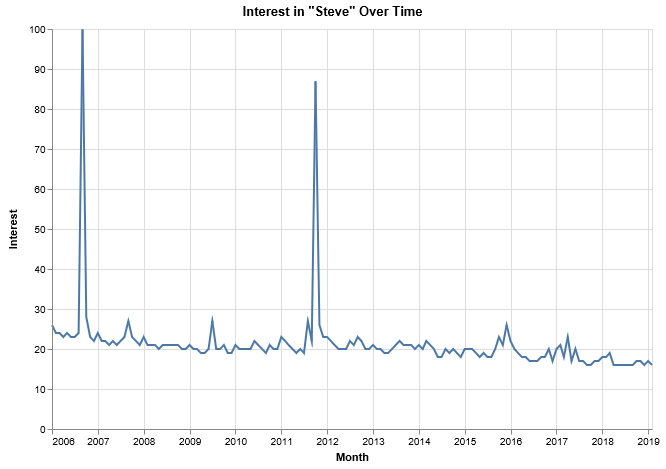

```python
VegaLite(google_trends)
```

### Steves as Internet Memes

[figure not shown]

### Steves as Heros

[figure not shown]

### In Song Lyrics

1. **"Hey Stephen" Taylor Swift**
2. "St. Stephen" Greatful Dead
3. "Steven's Last Night in Town"
4. **"Stephen" Ke\$sha**
5. "Steven" Alice Cooper
6. "Steve McQueen" Sherly Crow
7. "Steve McQueen" Drive-By Truckers
8. "Stephen" Gene Loves Jezebel
9. "Steve Lacy" Harry Connick, Jr.
10. "Steve Biko (Stir It Up)" A Tribe Called Quest
11. "Steven Seagal" Droids Attack

...

### Steve (atmospheric phenomenon)

[figure not shown]

# A Brief History of Steves

```python
IFrame('https://www.youtube.com/embed/nEea_wNQUM8?controls=0&amp;start=229', width=600, height=400)
```

[video not shown]

# Questions?

Such as:

- Can I change my name to Steve?
- When do I call someone ˈstiːvən vs. ˈʃtɛfan?
- What about Stephen Feinberg?
- What about Kevin McCarthy?

## Supplementary Materials

### Colbert on Stephen vs. Steve

```python
YouTubeVideo('JX3sD7FpsGM', width=600, height=400)
```

[video not shown]

### Is Kevin McCarthy an honorary Steve?

```python
YouTubeVideo('nFyOd1kNVQA', start=436)
```

[video not shown]